# Taylor Series

# Setup

## Load libraries

```r
suppressPackageStartupMessages( {
  library(RColorBrewer)
} )
```

## Color palettes

```r
pal <- brewer.pal(11, name="Spectral")
cl1 <- "red4"
cl2 <- "peru"
```

# Introduction

Taylor expansions allow us to approximate solutions/functions when $x\rightarrow 0$. Largely about taking non-polynomial functions and finding polynomials that approximate them near some angle. Why do this? Polynomials are *much* easier to deal with than other functions, such as cosine, etc. They are easier to compute derivatives, integrals.

## General form

At $x-0$:

$P(x)=f(0) + \dfrac{df}{dx}(0)\dfrac{x^1}{1!} + \dfrac{d^2f}{dx^2}(0)\dfrac{x^2}{2!} + \dfrac{d^3f}{dx^3}(0)\dfrac{x^3}{3!} + \dfrac{d^4f}{dx^4}(0)\dfrac{x^4}{4!} + ...$

At any point $x=a$:

$P(x)=f(a) + \dfrac{df}{dx}(a)\dfrac{(x-a)^1}{1!} + \dfrac{d^2f}{dx^2}(a)\dfrac{(x-a)^2}{2!} + \dfrac{d^3f}{dx^3}(a)\dfrac{(x-a)^3}{3!} + \dfrac{d^4f}{dx^4}(a)\dfrac{(x-a)^4}{4!} + ...$

# Practice

The easiest example of a Taylor series is $e^x$, since $\dfrac{d(e^x)}{dx}=e^x$, i.e. its derivative is the same as the original function! So using the general form above…

$P(e^x)=1 + x + \dfrac{1}{2}x^2 + \dfrac{1}{6}x^3 + \dfrac{1}{24}x^4 + ...$

For $e^{-x^2}$,

$P(e^{-x^2})=1 - x^2 + 0x^3 + \dfrac{1}{2}x^4 + ...$

## Example: $e^{-x^2}$, $e^x$

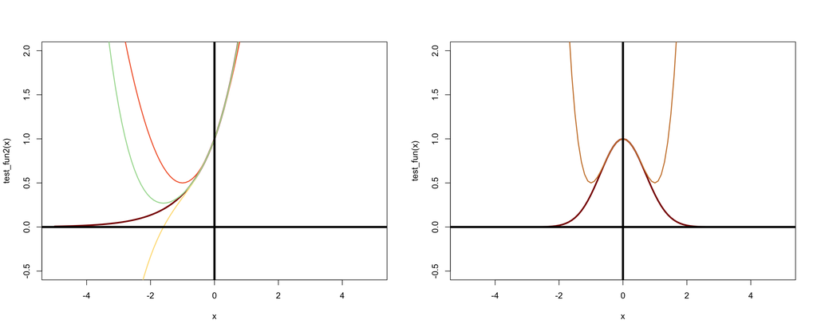

```r
e <- exp(1)

test_fun <- function(x) {
  e <- exp(1)
  y <- e^(-x^2)
  return(y)
}

tay_fun <- function(x) {
  e <- exp(1)
  y <- 1-(x^2)+0.5*x^4
  return(y)
}

test_fun2 <- function(x) {
  e <- exp(1)
  y <- e^x
  return(y)
}

tay_fun2 <- function(x) {
  e <- exp(1)
  y <- 1+x+(0.5*x^2)
  return(y)
}

tay_fun2_2 <- function(x) {
  e <- exp(1)
  y <- 1+x+(0.5*x^2)+((1/6)*(x^3))
  return(y)
}

tay_fun2_3 <- function(x) {
  e <- exp(1)
  y <- 1+x+(0.5*x^2)+((1/6)*(x^3))+((1/24)*(x^4))
  return(y)
}

x <- seq(-5, 5, by=0.1)

par(mfrow=c(1,2))

plot(x, test_fun2(x), type="l", col=cl1, lwd=3, ylim=c(-0.5,2))
lines(x, tay_fun2(x), col=pal[3], lwd=2)
lines(x, tay_fun2_2(x), col=pal[5], lwd=2)
lines(x, tay_fun2_3(x), col=pal[8], lwd=2)
abline(h=0, v=0, lwd=4)

plot(x, test_fun(x), type="l", col=cl1, lwd=3, ylim=c(-0.5,2))
lines(x, tay_fun(x), col=cl2, lwd=2)
abline(h=0, v=0, lwd=4)
```

## Example: $y=cosx$

Cosine form:

$cos(x)=1$ at $x=0$. Derivative is $\dfrac{d(cos)}{dx}(0)=-sin(0)=0$.

Polynomial form:

Generally, $P(x)=c_0 + c_1x + c_2x^2$. We know that $cos(0)=1$; therefore, $c_0$, giving us $P(x)=1 + c_1x + c_2x^2$. Deriving that expression, we get $\dfrac{dP}{dx}(0)=c_1 + 2c_20=c_1$.

$c_0=1$ $c_1=0$

Now we have $P(x)=1 + 0x + c_2x^2$ and are free to change $x_2$ so we can take advantage of the fact that the derivative $-sinx$ curves downward upon moving away from 0, i.e. it has a negative second derivative. Even though the rate of change is 0 at that point, the rate of change itself is decreasing at that point. Making sure that the second derivatives match will ensure that the original curve and polynomial curve at the same rate.

$\dfrac{d^2P}{dx^2}(x)=2c_2=-1$ $c_2=-1/2$

Steps:

1. *Original*: $cos(x) \xrightarrow {x \rightarrow 0}1$; *polynomial*: $P(x)=1 + 0x + c_2x^2$
- 1st term is 1 b/c cos(0) is 1
- 2nd term is 0 b/c -sin(0) is 0
2. *1st derivative*: $-sin(0)=0$; *polynomial*: $\dfrac{dP}{dx}(x)=0 + 2c_2x$
3. *2nd derivative*: $-cos(0)=-1$; *polynomial*: $\dfrac{d^2P}{dx^2}(x)=2c_2$

**Polynomial**: $P(x)=1 - \dfrac{1}{2}x^2$

```r
## first and second derivatives
D( expression( cos(x) ), "x" ) # -sinx
```

```
## -sin(x)
```

```r
D( expression( -sin(x) ), "x" ) # -cosx
```

```
## -cos(x)
```

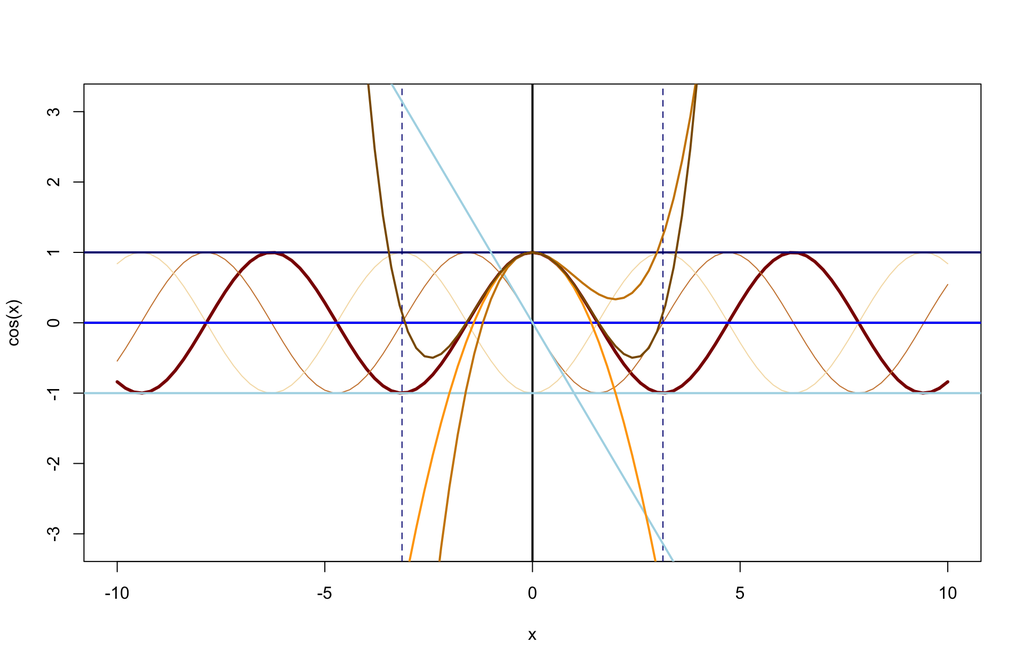

```r
## set colors
pal <- brewer.pal(8, name="Spectral")
cl1 <- "red4"
cl2 <- "peru"

## initiate x
x <- seq(-10,10,by=0.2)

## plot
plot(x, cos(x), type="l", col=cl1, lwd=3, ylim=c(-pi,pi))
lines(x, -sin(x), col=cl2)
lines(x, -cos(x), col="wheat")
abline(h=0, v=0, lwd=2)
abline(v=pi, col="navy", lty=2)
abline(v=-pi, col="navy", lty=2)

# original solution is 1
abline(h=1, col="navy", lwd=2)

# 1st derivative solution is 0
abline(h=0, col="blue", lwd=2)

# 2nd derivative solution is -1
abline(h=-1, col="lightblue", lwd=2)
abline(a=0, b=-1, col="lightblue", lwd=2)

# taylor expansion
lines(x, (1-(0.5*x^2)), col="orange", lwd=2)
lines(x, (1-(0.5*x^2)+(1/6)*x^3), col="orange3", lwd=2) # add 3rd term, 1/6 b/c 3*2*1=6
lines(x, (1-(0.5*x^2)+(1/24)*x^4), col="orange4", lwd=2) # add 4th term, 1/24 b/c 4*3*2*1=24
```

Now let’s try with brewer palette colors…

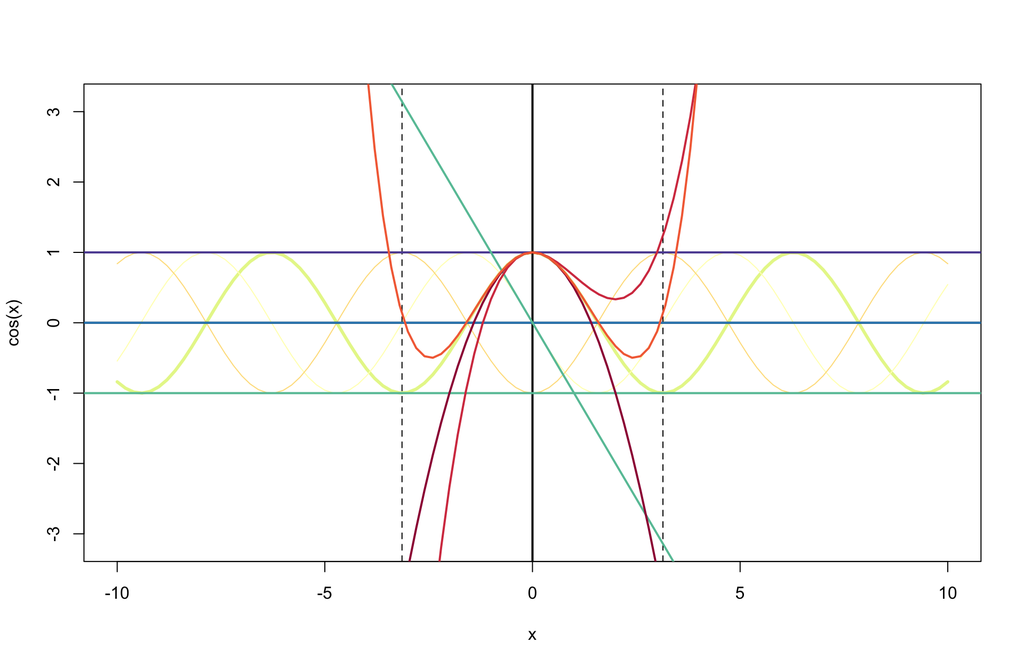

```r
## plot
n <- 11
pal <- brewer.pal(11, name="Spectral")
plot(x, cos(x), type="l", col=pal[[7]], lwd=3, ylim=c(-pi,pi))
lines(x, -sin(x), col=pal[[6]])
lines(x, -cos(x), col=pal[[5]])
abline(h=0, v=0, lwd=2)
abline(v=pi, lty=2)
abline(v=-pi, lty=2)

# original solution is 1
abline(h=1, col=pal[[n]], lwd=2)

# 1st derivative solution is 0
abline(h=0, col=pal[[n-1]], lwd=2)

# 2nd derivative solution is -1
abline(h=-1, col=pal[[n-2]], lwd=2)
abline(a=0, b=-1, col=pal[[n-2]], lwd=2)

# taylor expansion
lines(x, (1-(0.5*x^2)), col=pal[[1]], lwd=2)
lines(x, (1-(0.5*x^2)+(1/6)*x^3), col=pal[[2]], lwd=2) # add 3rd term, 1/6 b/c 3*2*1=6
lines(x, (1-(0.5*x^2)+(1/24)*x^4), col=pal[[3]], lwd=2) # add 4th term, 1/24 b/c 4*3*2*1=24
```

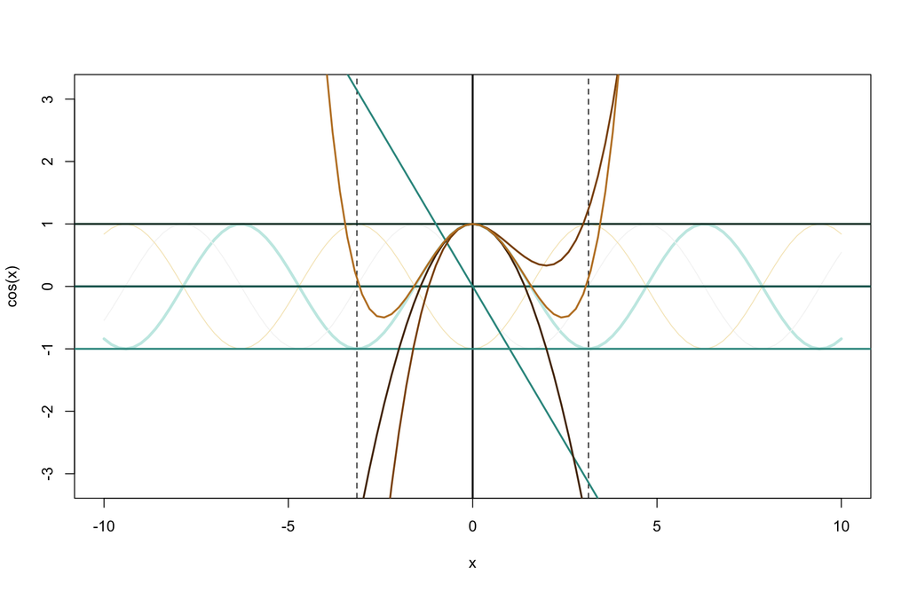

```r
## plot
n <- 11
pal <- brewer.pal(n, name="BrBG")
plot(x, cos(x), type="l", col=pal[[7]], lwd=3, ylim=c(-pi,pi))
lines(x, -sin(x), col=pal[[6]])
lines(x, -cos(x), col=pal[[5]])
abline(h=0, v=0, lwd=2)
abline(v=pi, lty=2)
abline(v=-pi, lty=2)

# original solution is 1
abline(h=1, col=pal[[n]], lwd=2)

# 1st derivative solution is 0
abline(h=0, col=pal[[n-1]], lwd=2)

# 2nd derivative solution is -1
abline(h=-1, col=pal[[n-2]], lwd=2)
abline(a=0, b=-1, col=pal[[n-2]], lwd=2)

# taylor expansion
lines(x, (1-(0.5*x^2)), col=pal[[1]], lwd=2)
lines(x, (1-(0.5*x^2)+(1/6)*x^3), col=pal[[2]], lwd=2) # add 3rd term, 1/6 b/c 3*2*1=6
lines(x, (1-(0.5*x^2)+(1/24)*x^4), col=pal[[3]], lwd=2) # add 4th term, 1/24 b/c 4*3*2*1=24
```

So how good is this approximation? Let’s try it out for, say, 0.1…

```r
cos(0.1)
```

```
## [1] 0.9950042
```

```r
1-0.5*(0.1^2)
```

```
## [1] 0.995
```

Pretty damn close!